# Do Overdraft infocards help users top-up and avoid arrears? (Part II)

In order to answer the question above, we ran 3 A/B test experiments:

- **Sixty days usage infocard test** - Displays information that users started using their arranged overdraft, and is meant to be displayed a repeated time 60 days after it was last shown if applicable
- **Fifty percent usage infocard test** - Displays information that users have crossed 50% of their arranged overdraft limit. In this test we have 2 variants:
  - One infocard that displays the amount of overdraft users
  - One infocard that displays that they are using 50% of their overdraft limit
- **Quarterly top-up infocard test** - Displays information that users will be charged their overdraft in one week, sent quarterly (since overdraft interest is changed quarterly)

[Here](https://www.figma.com/file/kaE5VHKLfu82RekVXnd8Aa/Overdraft-experiments?node-id=7%3A182) you can find the designs used for each of these infocards.

## Contents

- Quarterly top-up reminder infocard test results
  - The Sample
  - Infocard Interactions
  - Top-up Rates
  - 3 month arrears arrears
  - 6 month write-offs
- Sixty days usage infocard test results
  - 3 month arrears
  - 6 month write-offs
- Fifty Percent usage infocard test results
  - 3 month arrears
  - 6 month write-offs

## Experimental Design

For each of the infocards we want to test, users that meet the infocart trigger conditions will be randomly split into 2 groups:

- One control group that will not receive the infocard
- One variant group that will receive the infocard

This split was automatically handled by plutonium (the overdraft microservice) as soon as the users met the trigger condition.

### Hypothesis

For each of the experiments, we have 2 success measures, so we'll be defining hypothesis for each of these:

**Top-up rates increase**

- **H0:** There are no significant differences in top-up rate within 7 days of meeting the trigger condition
- **H1:** The top-up rates for the variant group are significantly higher than the control group within 7 days of meeting the trigger condition

**Arrears rates decrease**

- **H0:** There are no significant differences in arrears rates within 3 months of meeting the trigger condition
- **H1:** The arrears rates for the variant group are significantly lower than the control group within 3 months of meeting the trigger condition

**Write-off rates decrease**

- **H0:** There are no significant differences in write-off rates within 6 months of meeting the trigger condition
- **H1:** The write-off rates for the variant group are significantly lower than the control group within 6 months of meeting the trigger condition

### Experiment Analysis & Timings

In the [part I](https://research.tech26.de/reports/20210525_overdraft_infocard_ab_tests.html) of the analysis of this experiment, run in June 2021 you can find the top-up rates and preliminary arrears results for the sixty days usage infocard and fifty percent usage infocard. For the conclusions of this experiment, we will consider the top-up results from the first part of the results (since there were no visible changes in these since then), and the remaining conclusions will come from this second part of the research. [Here](https://docs.google.com/presentation/d/1hWUr0Pg-neOKaSv1_JjTMSZENBsatGxZtGZmbEu-C9k/edit#slide=id.g10f990ea5de_0_19) you can find a summary of the main results from both experiments combined.

We will be running a Z-Test for each of the experiments and success measures, and assume a significance level of 0.05.

For quarterly top-ups, since these are only sent once each quarter, we’re considering results from end of Q2 and end of Q3 for top-ups and arrears, and only end of Q2 for write-offs.

### Sample split

In the image below we can see the sample split for each of the experiments:

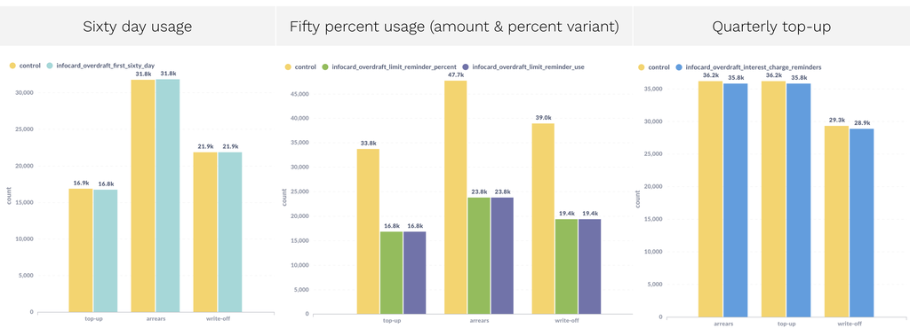

Both variants in the fifty percent usage experiment share the same control group, so even though the control group looks twice as large here, it corresponds to the same proportion of variant users as in the other 2 experiments.

## Key take-aways:

### Sixty Day Infocard Experiment:

- We have significantly higher top-up rates for the variant group in all tests of the sixty day experiment. This means that for all users that received the infocars, we verified a 1 percentage point increase in top-up rates for users that received the infocard (from 67.8% to 68.8%).
- However, here we didn’t see any significant decreases in the arrears or write-off rates.
- **Recommendation** : Given that top-up rates results for this experiment were quite positive, **we would recommend adopting this infocard moving forward.**

### Fifty Percent Infocard Experiment:

- Here we didn’t see any significant decreases in the top-up or write-off rates for both variants of this experiment.
- We see a significant decrease in arrears rates for all users in the percent variant, but not when filtering for users who logged in the app. Based on that, the percent variant seems to perform slightly better than the amount variant.
- **Recommendation** : Since we didn't find a consistently favorable trend for variant users in this experiment (neither for top-up rates nor arrears rates), we don’t discourage the usage of this infocard, but **we would recommend re-running this experiment at a higher usage threshold.**

### Quarterly Top-up Infocard Experiment:

- For all users that received the infocards, we verified a 0.9 percentage point increase in top-up rates for variant users (from 50.2% to 51.1%).
- Here we didn’t see any significant decreases in the write-off rates. We see a significant decrease in arrears rates for all users, but not when filtering for users who logged in the app.
- **Recommendation** : Given that top-up rates results for this experiment were quite positive, **we would recommend adopting this infocard moving forward.**

For some of the arrears rates for the comparison of Viewed inforcard (vs. login in control) and Clicked inforcard (vs. login in control), we found some undesirable cases where the variant arrears were significantly higher than control. Given that these variant users are being compared against a different control group (since control users didn't receive an infocard that could be viewed/ clicked), and these arrears results don't seem to materialize into significant write-off differences, we will not be considering these results in the following conclusions.

# Quarterly top-up reminder infocard test results

## The Sample

Below we can see that we have an evenly split sample of about 36K users for this experiment. Even though the write-off subset of users is smaller than this one, it is equally split as well (as seen in the sample split above).

[interactive chart not shown]

## Infocard Interactions

Below you have an overview of how users interact with the N26 app after being selected for this experiment.

|  | event_type | no_event | has_event | perc_has_event |
| --- | --- | --- | --- | --- |
| 0 | logins | 10470 | 25329 | 70.8 |
| 1 | views | 13349 | 22450 | 62.7 |
| 2 | dismissed_clicked | 24620 | 11179 | 31.2 |
| 3 | action_clicked | 33424 | 2375 | 6.6 |

[interactive chart not shown]

## Top-up Rates

|  | user_split | top_up_type | n_users | login_users | infocard_view_users | infocard_clicked_users | perc_all_users | perc_login_users | perc_infocard_view_users | perc_infocard_click_users |
| --- | --- | --- | --- | --- | --- | --- | --- | --- | --- | --- |
| 0 | control | Has Top-up | 18177 | 17340 | 0 | 0 | 50.2 | 67.9 | NaN | NaN |
| 1 | variant | Has Top-up | 18287 | 17477 | 14884 | 1741 | 51.1 | 69.0 | 66.3 | 73.3 |
| 2 | control | No Top-up | 18001 | 8179 | 0 | 0 | 49.8 | 32.1 | NaN | NaN |
| 3 | variant | No Top-up | 17512 | 7852 | 7566 | 634 | 48.9 | 31.0 | 33.7 | 26.7 |

[interactive chart not shown]

|  | test | larger_p_value | smaller_p_value | result |
| --- | --- | --- | --- | --- |
| 0 | All users with top-up | 0.01 | 0.99 | Variant top-up rates are significantly higher than the control (reject H0) |
| 1 | Users that logged-in | 0.01 | 0.99 | Variant top-up rates are significantly higher than the control (reject H0) |
| 2 | Viewed inforcard (vs. login in control) | 1.00 | 0.00 | Samples have similar top-up rates (fail to reject H0) |
| 3 | Clicked inforcard (vs. login in control) | 0.00 | 1.00 | Variant top-up rates are significantly higher than the control (reject H0) |

**Conclusion:** We have significantly higher top-up rates for the variant group in almost all tests of the quarterly top-up experiment (except for users who viewed the infocard). This means that for all users that received the infocards, we verified a 0.9 percentage point increase in top-up rates for variant users (from 50.2% to 51.1%)

## 3 month arrears

|  | user_split | arrears_type | n_users | login_users | infocard_view_users | infocard_clicked_users | perc_all_users | perc_login_users | perc_infocard_view_users | perc_infocard_click_users |
| --- | --- | --- | --- | --- | --- | --- | --- | --- | --- | --- |
| 0 | control | Has Arrears | 5669 | 4119 | 0 | 0 | 15.7 | 16.1 | NaN | NaN |
| 1 | variant | Has Arrears | 5438 | 3971 | 3849 | 374 | 15.2 | 15.7 | 17.1 | 15.7 |
| 2 | control | No Arrears | 30509 | 21400 | 0 | 0 | 84.3 | 83.9 | NaN | NaN |
| 3 | variant | No Arrears | 30361 | 21358 | 18601 | 2001 | 84.8 | 84.3 | 82.9 | 84.3 |

[interactive chart not shown]

|  | test | larger_p_value | smaller_p_value | result |
| --- | --- | --- | --- | --- |
| 0 | All users with top-up | 0.96 | 0.04 | Variant arrears rates are significantly lower than the control (reject H0) |
| 1 | Users that logged-in | 0.92 | 0.08 | Samples have similar arrears rates (fail to reject H0) |
| 2 | Viewed inforcard (vs. login in control) | 0.00 | 1.00 | Variant arrears rates are significantly higher the control (reject H0 but undesirable effect) |
| 3 | Clicked inforcard (vs. login in control) | 0.69 | 0.31 | Samples have similar arrears rates (fail to reject H0) |

## 6 month write-offs

|  | user_split | write_off_type | n_users | login_users | infocard_view_users | infocard_clicked_users | perc_all_users | perc_login_users | perc_infocard_view_users | perc_infocard_click_users |
| --- | --- | --- | --- | --- | --- | --- | --- | --- | --- | --- |
| 0 | control | Has Write-off | 676 | 324 | 0 | 0 | 1.9 | 1.3 | NaN | NaN |
| 1 | variant | Has Write-off | 662 | 330 | 254 | 31 | 1.8 | 1.3 | 1.1 | 1.3 |
| 2 | control | No Write-off | 35502 | 25195 | 0 | 0 | 98.1 | 98.7 | NaN | NaN |
| 3 | variant | No Write-off | 35137 | 24999 | 22196 | 2344 | 98.2 | 98.7 | 98.9 | 98.7 |

[interactive chart not shown]

|  | test | larger_p_value | smaller_p_value | result |
| --- | --- | --- | --- | --- |
| 0 | All users with top-up | 0.58 | 0.42 | Samples have similar write_off rates (fail to reject H0) |
| 1 | Users that logged-in | 0.37 | 0.63 | Samples have similar write_off rates (fail to reject H0) |
| 2 | Viewed inforcard (vs. login in control) | 0.92 | 0.08 | Samples have similar write_off rates (fail to reject H0) |
| 3 | Clicked inforcard (vs. login in control) | 0.44 | 0.56 | Samples have similar write_off rates (fail to reject H0) |

**Conclusion:** Here we have no significant decrease in the write-off rates.

# Sixty days usage infocard test results

## 3 month arrears

|  | user_split | arrears_type | n_users | login_users | infocard_view_users | infocard_clicked_users | perc_all_users | perc_login_users | perc_infocard_view_users | perc_infocard_click_users |
| --- | --- | --- | --- | --- | --- | --- | --- | --- | --- | --- |
| 0 | control | Has Arrears | 1766 | 1718 | 0 | 0 | 5.6 | 5.8 | NaN | NaN |
| 1 | variant | Has Arrears | 1743 | 1700 | 1377 | 175 | 5.5 | 5.8 | 6.1 | 6.8 |
| 2 | control | No Arrears | 30023 | 27724 | 0 | 0 | 94.4 | 94.2 | NaN | NaN |
| 3 | variant | No Arrears | 30105 | 27821 | 21189 | 2390 | 94.5 | 94.2 | 93.9 | 93.2 |

[interactive chart not shown]

|  | test | larger_p_value | smaller_p_value | result |
| --- | --- | --- | --- | --- |
| 0 | All users with top-up | 0.68 | 0.32 | Samples have similar arrears rates (fail to reject H0) |
| 1 | Users that logged-in | 0.65 | 0.35 | Samples have similar arrears rates (fail to reject H0) |
| 2 | Viewed inforcard (vs. login in control) | 0.10 | 0.90 | Samples have similar arrears rates (fail to reject H0) |
| 3 | Clicked inforcard (vs. login in control) | 0.02 | 0.98 | Variant arrears rates are significantly higher the control (reject H0 but undesirable effect) |

**Conclusion:** Here we generally have no significant decrease in the arrears rates. We have an undesirable increase of 1 percentage point for variant users who clicked on the infocars vs. login users in control.

## 6 month write-offs

|  | user_split | write_off_type | n_users | login_users | infocard_view_users | infocard_clicked_users | perc_all_users | perc_login_users | perc_infocard_view_users | perc_infocard_click_users |
| --- | --- | --- | --- | --- | --- | --- | --- | --- | --- | --- |
| 0 | control | Has Write-off | 93 | 90 | 0 | 0 | 0.4 | 0.4 | NaN | NaN |
| 1 | variant | Has Write-off | 87 | 86 | 59 | 8 | 0.4 | 0.4 | 0.4 | 0.5 |
| 2 | control | No Write-off | 21951 | 20423 | 0 | 0 | 99.6 | 99.6 | NaN | NaN |
| 3 | variant | No Write-off | 22000 | 20461 | 16205 | 1767 | 99.6 | 99.6 | 99.6 | 99.5 |

[interactive chart not shown]

|  | test | larger_p_value | smaller_p_value | result |
| --- | --- | --- | --- | --- |
| 0 | All users with top-up | 0.57 | 0.43 | Samples have similar write_off rates (fail to reject H0) |
| 1 | Users that logged-in | 0.46 | 0.54 | Samples have similar write_off rates (fail to reject H0) |
| 2 | Viewed inforcard (vs. login in control) | 0.78 | 0.22 | Samples have similar write_off rates (fail to reject H0) |
| 3 | Clicked inforcard (vs. login in control) | 0.18 | 0.82 | Samples have similar write_off rates (fail to reject H0) |

**Conclusion:** Here we have no significant decrease in the write-off rates.

# Fifty Percent usage infocard test results

## 3 month arrears

|  | user_split | arrears_type | n_users | login_users | infocard_view_users | infocard_clicked_users | perc_all_users | perc_login_users | perc_infocard_view_users | perc_infocard_click_users |
| --- | --- | --- | --- | --- | --- | --- | --- | --- | --- | --- |
| 0 | control | Has arrears | 5658 | 4781 | 0 | 0 | 11.9 | 11.5 | NaN | NaN |
| 1 | reminder_percent | Has arrears | 2676 | 2310 | 2434 | 646 | 11.2 | 11.1 | 12.0 | 14.9 |
| 2 | reminder_use | Has arrears | 2765 | 2333 | 2513 | 740 | 11.6 | 11.3 | 12.4 | 15.8 |
| 3 | control | No arrears | 42051 | 36741 | 0 | 0 | 88.1 | 88.5 | NaN | NaN |
| 4 | reminder_percent | No arrears | 21148 | 18443 | 17780 | 3689 | 88.8 | 88.9 | 88.0 | 85.1 |
| 5 | reminder_use | No arrears | 21051 | 18360 | 17681 | 3957 | 88.4 | 88.7 | 87.6 | 84.2 |

[interactive chart not shown]

#### Arrears Z-Test results for the Percent Reminder Infocard

|  | test | larger_p_value | smaller_p_value | result |
| --- | --- | --- | --- | --- |
| 0 | All users with top-up | 0.99 | 0.01 | Variant arrears rates are significantly lower than the control (reject H0) |
| 1 | Users that logged-in | 0.92 | 0.08 | Samples have similar arrears rates (fail to reject H0) |
| 2 | Viewed inforcard (vs. login in control) | 0.03 | 0.97 | Variant arrears rates are significantly higher the control (reject H0 but undesirable effect) |
| 3 | Clicked inforcard (vs. login in control) | 0.00 | 1.00 | Variant arrears rates are significantly higher the control (reject H0 but undesirable effect) |

**Conclusion:** Here we have somewhat contradictory results, with a significant decrease for all variant users of 0.7 percentage points, no significant changes for users that logged-in, and undesirable significantly higher arrears rates for the variant groups who either viewed or clicked the infocard (with increases of 0.5 percentage points and 3.4 percentage points respectively).

#### Arrears Z-Test results for the Usage Reminder Infocard

|  | test | larger_p_value | smaller_p_value | result |
| --- | --- | --- | --- | --- |
| 0 | All users with top-up | 0.84 | 0.16 | Samples have similar top-up rates (fail to reject H0) |
| 1 | Users that logged-in | 0.81 | 0.19 | Samples have similar top-up rates (fail to reject H0) |
| 2 | Viewed inforcard (vs. login in control) | 0.00 | 1.00 | Variant arrears rates are significantly higher the control (reject H0 but undesirable effect) |
| 3 | Clicked inforcard (vs. login in control) | 0.00 | 1.00 | Variant arrears rates are significantly higher the control (reject H0 but undesirable effect) |

**Conclusion:** And here we find no significant differences between variant and control in the all users and users who logged in groups, but we do have undesirable significantly higher arrears rates for the variant groups who either viewed or clicked the infocard (with increases of 0.9 percentage points and 4.3 percentage points respectively).

## 6 month write-offs

|  | user_split | write_off_type | n_users | login_users | infocard_view_users | infocard_clicked_users | perc_all_users | perc_login_users | perc_infocard_view_users | perc_infocard_click_users |
| --- | --- | --- | --- | --- | --- | --- | --- | --- | --- | --- |
| 0 | control | Has write-off | 512 | 345 | 0 | 0 | 1.3 | 1.0 | NaN | NaN |
| 1 | reminder_percent | Has write-off | 250 | 185 | 185 | 38 | 1.3 | 1.1 | 1.1 | 1.0 |
| 2 | reminder_use | Has write-off | 235 | 156 | 157 | 32 | 1.2 | 0.9 | 0.9 | 0.8 |
| 3 | control | No write-off | 38624 | 33787 | 0 | 0 | 98.7 | 99.0 | NaN | NaN |
| 4 | reminder_percent | No write-off | 19240 | 16822 | 16767 | 3754 | 98.7 | 98.9 | 98.9 | 99.0 |
| 5 | reminder_use | No write-off | 19274 | 16840 | 16789 | 4052 | 98.8 | 99.1 | 99.1 | 99.2 |

[interactive chart not shown]

#### Write-off Z-Test results for the Percent Reminder Infocard

|  | test | larger_p_value | smaller_p_value | result |
| --- | --- | --- | --- | --- |
| 0 | All users with top-up | 0.63 | 0.37 | Samples have similar write_off rates (fail to reject H0) |
| 1 | Users that logged-in | 0.17 | 0.83 | Samples have similar write_off rates (fail to reject H0) |
| 2 | Viewed inforcard (vs. login in control) | 0.14 | 0.86 | Samples have similar write_off rates (fail to reject H0) |
| 3 | Clicked inforcard (vs. login in control) | 0.45 | 0.55 | Samples have similar write_off rates (fail to reject H0) |

**Conclusion:** Here we have no significant decrease in the write-off rates.

#### Write-off Z-Test results for the Usage Reminder Infocard

|  | test | larger_p_value | smaller_p_value | result |
| --- | --- | --- | --- | --- |
| 0 | All users with top-up | 0.88 | 0.12 | Samples have similar write_off rates (fail to reject H0) |
| 1 | Users that logged-in | 0.85 | 0.15 | Samples have similar write_off rates (fail to reject H0) |
| 2 | Viewed inforcard (vs. login in control) | 0.80 | 0.20 | Samples have similar write_off rates (fail to reject H0) |
| 3 | Clicked inforcard (vs. login in control) | 0.83 | 0.17 | Samples have similar write_off rates (fail to reject H0) |

**Conclusion:** Here we have no significant decrease in the write-off rates.